# State Farm Data Science Assessment - Lu Zheng

I would like to first provide a summary of the results I obtained before we move to the details. Based on the instructions, I developed two models: Logistic Regression and Random Forest. Below is a summary of the training auc and test auc I achieved using the best models after feature engineering and parameter tuning. The two **result.csv** were also generated from the two models.

| Model/AUC | Training | Test |
| --- | --- | --- |
| Logistic Regression | 0.910 | 0.906 |
| Random Forest | 0.978 | 0.936 |

In this note book, I will cover:

- Data Exploration
- Data Processing and Feature Engineering
- Feature Selection
- Model Building and Fine-tuning
- Generate Prediction on Hold-out set

```python
# import all necessary packages needed

import pandas as pd
import numpy as np
import matplotlib.pyplot as plt
import seaborn as sns
import warnings
from sklearn.decomposition import PCA
from sklearn.linear_model import LogisticRegression
from sklearn.ensemble import RandomForestClassifier
from sklearn.feature_selection import SelectFromModel
from sklearn.model_selection import train_test_split
from eli5.sklearn import PermutationImportance
from sklearn.model_selection import cross_validate
from sklearn.compose import ColumnTransformer
from sklearn.model_selection import train_test_split
from sklearn.pipeline import Pipeline
from sklearn.impute import SimpleImputer
import eli5
from sklearn.model_selection import cross_val_score, GridSearchCV
from eli5.sklearn import PermutationImportance
from sklearn.metrics import roc_auc_score
warnings.filterwarnings('ignore')
%matplotlib inline
```

## 1. Data Exploration

In this section, we will take a close look at the data, and perform some basic quality check such as missing value, outliers, etc. on the data.

```python
train = pd.read_csv('../data/exercise_01_train.csv')
holdout = pd.read_csv('../data/exercise_01_test.csv')
```

```python
train.head()
```

|  | x0 | x1 | x2 | x3 | x4 | x5 | x6 | x7 | x8 | x9 | ... | x91 | x92 | x93 | x94 | x95 | x96 | x97 | x98 | x99 | y |
| --- | --- | --- | --- | --- | --- | --- | --- | --- | --- | --- | --- | --- | --- | --- | --- | --- | --- | --- | --- | --- | --- |
| 0 | 10.142889 | -15.675620 | 3.583176 | -22.397489 | 27.221894 | -34.110924 | -0.072829 | -0.544444 | 0.997601 | -2.691778 | ... | 1.916575 | 5.240820 | euorpe | 2.431170 | 0.454074 | -18.572032 | -14.291524 | 0.178579 | 18.110170 | 0 |
| 1 | -52.214630 | 5.847135 | -10.902843 | -14.132351 | 20.588574 | 36.107322 | 0.115023 | 0.276093 | -0.699168 | -0.972708 | ... | 0.370941 | -3.794542 | asia | 2.592326 | 31.921833 | 3.317139 | 10.037003 | -1.930870 | -3.486898 | 0 |
| 2 | 67.718500 | 2.064334 | 12.394186 | -18.667102 | 47.465504 | -50.373658 | 0.253707 | 1.068968 | 2.939713 | 2.691218 | ... | 1.449817 | 12.470532 | asia | 7.143821 | 9.401490 | -10.604968 | 7.643215 | -0.842198 | -79.358236 | 0 |
| 3 | -28.003111 | 8.565128 | -8.592092 | 5.918960 | -3.224154 | 78.315783 | -0.879845 | 1.176889 | -2.414752 | 0.589646 | ... | -3.274733 | 3.484450 | asia | -4.998195 | -20.312810 | 14.818524 | -9.180674 | 1.356972 | 14.475681 | 0 |
| 4 | 80.703016 | 30.736353 | -30.101857 | -21.201140 | -91.946233 | -47.469246 | -0.646831 | -0.578398 | 0.980849 | -1.426112 | ... | -0.644261 | 4.082783 | asia | -0.012556 | -29.334324 | 1.734433 | -12.262072 | -0.043228 | -19.003881 | 0 |

5 rows × 101 columns

```python
print(train.shape)
```

```
(40000, 101)
```

We have 40000 rows in training data, 100 features, and a binary response variable.

```python
print('Positive class: ', sum(train['y']), sum(train['y']) / 40000)
print('Negative class: ', 40000 - sum(train['y']), (40000 - sum(train['y'])) / 40000)
```

```
Positive class:  8047 0.201175
Negative class:  31953 0.798825
```

```python
categorical = ['x' + str(i) for i in range(len(train.dtypes) - 1) if train.dtypes[i] == 'O']
numerical = ['x' + str(i) for i in range(len(train.dtypes) - 1) if train.dtypes[i] != 'O']
print('Categorical variables: ', train[categorical].shape[1])
print('Numerical variables: ', train[numerical].shape[1])
```

```
Categorical variables:  6
Numerical variables:  94
```

**Check outliers**  
Usually, I use a box plot and a histogram to check the outliers. But we have 94 features in here, to make the notebook shorter, I just plot the histogram and box plot for one variable. After checking the plots for all columns, I did not found noticeable outliers. Also since the scale of all variable are relatively comparable, I think no standardization is needed in this case.

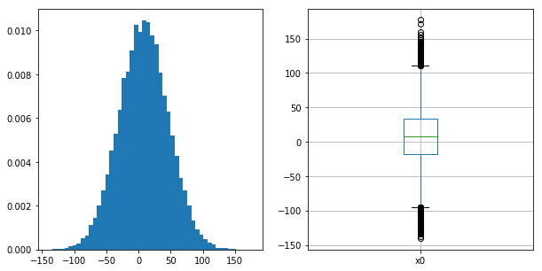

```python
fig, ax = plt.subplots(1,2, figsize = (10,5))
ax[0].hist(train[numerical[0]], density = True, bins = 50)
train.boxplot(column=[numerical[0]], grid=True)
```

Check missing values for training and hold-out dataset. Note that to make the notebook shorter, I only printed out the checking results for the first 5 columns.

```python
num_row = train.shape[0]
count = 0
for i in train.columns:
        temp = train[train[i].isnull()]
        if temp.shape[0] > 0 and count < 5:
            print(i + ' Missing value: ' + str(temp.shape[0]) + '; Percentage: ' +str(temp.shape[0] / num_row))
        count += 1
```

```
x0 Missing value: 14; Percentage: 0.00035
x1 Missing value: 10; Percentage: 0.00025
x2 Missing value: 6; Percentage: 0.00015
x3 Missing value: 10; Percentage: 0.00025
x4 Missing value: 6; Percentage: 0.00015
```

```python
num_row = holdout.shape[0]
count = 0
for i in holdout.columns:
        temp = holdout[holdout[i].isnull()]
        if temp.shape[0] > 0 and count < 5:
            print(i + ' Missing value: ' + str(temp.shape[0]) + '; Percentage: ' +str(temp.shape[0] / num_row))
        count += 1
```

```
x1 Missing value: 2; Percentage: 0.0002
x2 Missing value: 3; Percentage: 0.0003
x3 Missing value: 3; Percentage: 0.0003
x4 Missing value: 2; Percentage: 0.0002
```

Next let's further explore the categorical variables.

```python
for i in train[categorical].columns:
    print(i, len(train[categorical][i].unique()), train[categorical][i].unique())
```

```
x34 11 ['bmw' 'nissan' 'Honda' 'Toyota' 'volkswagon' 'tesla' 'chrystler' 'ford'
 'mercades' nan 'chevrolet']
x35 6 ['wednesday' 'thurday' 'friday' 'tuesday' 'monday' nan]
x41 37833 ['$-54.1' '$-229.32' '$243.68' ... '$1215.91' '$-723.78' '$-426.49']
x45 11 ['0.0%' '0.01%' '-0.01%' '0.02%' '-0.02%' '-0.0%' '-0.03%' '0.03%' '0.04%'
 '-0.04%' nan]
x68 13 ['Jun' 'July' 'May' 'Aug' 'Apr' 'Mar' 'Oct' 'sept.' 'Nov' 'Feb' 'Dev' nan
 'January']
x93 4 ['euorpe' 'asia' 'america' nan]
```

We have 6 categorical variables. Almost all categorical variables have less than 15 categories except for x41, which has 37833 unique values. I considered converting it to numerical variable by removing its dollar sign.

As for how to deal with the categorical variables, since we already have 100 features, directly applying one-hot encoding to categorical variables would further increase the number of features, and we usually expect less contribution from categorical variables than those numerical ones. Given our data size, 100 features were way enough. I decided to further explore each categorical variable and see if we could obtain more insights before we proceeded.

```python
train['x35'].replace('thur','thurday', inplace = True)
train['x35'].replace('fri','friday', inplace = True)
train['x35'].replace('wed', 'wednesday', inplace = True)
```

For each categorical variable, I plotted the class distribution for each category to see if there's any distinguishing category that we could work on.

```python
def group_data(col):
    df = pd.DataFrame(train.groupby([col,'y']).size() /
                               train.groupby(col).size()).reset_index().rename(columns = {0:'count'})
    return df
```

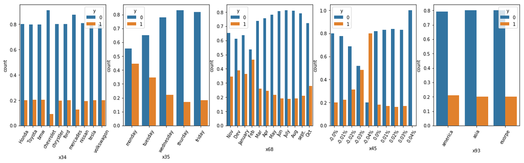

```python
plt.figure(figsize = (20, 5))

plt.subplot(1,5,1)
plt.xticks(rotation=60)
ax = sns.barplot(x='x34', y="count", hue="y", data = group_data('x34'))

plt.subplot(1,5,2)
plt.xticks(rotation=60)
ax = sns.barplot(x='x35', y="count", hue="y", data=group_data('x35'), order = ['monday', 'tuesday','wednesday',
                                                                       'thurday','friday' ])
plt.subplot(1,5,3)
plt.xticks(rotation=60)
ax = sns.barplot(x='x68', y="count", hue="y", data=group_data('x68'), order = ['Nov','Dev','January',
                                                                               'Feb','Mar', 'Apr',
                                                                       'May', 'Jun', 'July', 'Aug','sept.','Oct'])
plt.subplot(1,5,4)
plt.xticks(rotation=60)
ax = sns.barplot(x='x45', y="count", hue="y", data=group_data('x45'))

plt.subplot(1,5,5)
plt.xticks(rotation=60)
ax = sns.barplot(x='x93', y="count", hue="y", data=group_data('x93'))
```

From the previous exploration, we knew that the negative class accounts for 80% of the dataset. The bar chart above suggested that some categories have a significantly different class distribution from the overall positive/negative ratio. Therefore instead of encoding all categories for each variable, we could only encode those that may have a greater contribution to classification. The proposed encoding rules are as follows:

- x34: chevrolet, mercades: 1
- x35: monday, tuesday: 1
- x68: Nov, Dev, January, Feb: 1
- x45: <0: 1
- x93: drop

Take the first one as an example, if x34 is **chevrolet** or **mercades**, we encode it as 1, otherwise 0. The same idea applies to the remaining categorical variables.

## 2. Data Processing and Feature Engineering

Guided by the findings from data exploration sections, I performed data pre-processing including filling missing values and encoding categorical variables. As missing values only account for a small portion of the dataset, I decided to use simple mean(numerical variables)/mod(categorical variables) imputing method to handle them. Note that as we had no information on what each column represents, it would not make sense if we construct new features by combining multiple features. So the feature engineering in this section would primarily focus on addressing some key points we found in the data exploration part.

Note that we have identified column x41 as a numerical variable as it has 30k unique values. So let's first convert x41 from categorical to numerical.

```python
train['x41'] = train['x41'].map(lambda x: float(x[1:]) if not pd.isnull(x) else x)
holdout['x41'] = holdout['x41'].map(lambda x: float(x[1:]) if not pd.isnull(x) else x)
categorical.remove('x41')
numerical.append('x41')
```

Fill missing values with mean/mod.

```python
categorical_pipe = Pipeline([
    ('imputer', SimpleImputer(strategy='most_frequent', fill_value='missing'))
])

numerical_pipe = Pipeline([
    ('imputer', SimpleImputer(strategy='mean', fill_value = 'missing'))
])

preprocessing = ColumnTransformer(
    [('cat', categorical_pipe, categorical),
     ('num', numerical_pipe, numerical)])

train_transformed = pd.DataFrame(preprocessing.fit_transform(train), columns=categorical+numerical, )
holdout_transformed = pd.DataFrame(preprocessing.fit_transform(holdout), columns=categorical+numerical)
```

Convert categorical variables following the rules below:

- x34: chevrolet, mercades: 1
- x35: monday, tuesday: 1
- x68: Nov, Dev, January, Feb: 1
- x45: <0: 1
- x93: drop

```python
x34 = {'chevrolet', 'mercades'}
x35 = {'monday', 'tuesday'}
x68 = {'Nov','Dev', 'January', 'Feb'}
x45 = {'-0.01%', '-0.02%', '-0.02%', '-0.03%', '-0.04%'}
train_transformed['x34_new'] = train_transformed['x34'].map(lambda x: 1 if x in x34 else 0)
train_transformed['x35_new'] = train_transformed['x35'].map(lambda x: 1 if x in x35 else 0)
train_transformed['x68_new'] = train_transformed['x68'].map(lambda x: 1 if x in x68 else 0)
train_transformed['x45_new'] = train_transformed['x45'].map(lambda x: 1 if x in x45 else 0)

holdout_transformed['x34_new'] = holdout_transformed['x34'].map(lambda x: 1 if x in x34 else 0)
holdout_transformed['x35_new'] = holdout_transformed['x35'].map(lambda x: 1 if x in x35 else 0)
holdout_transformed['x68_new'] = holdout_transformed['x68'].map(lambda x: 1 if x in x68 else 0)
holdout_transformed['x45_new'] = holdout_transformed['x45'].map(lambda x: 1 if x in x45 else 0)

del(train_transformed['x93'])
del(holdout_transformed['x93'])
```

```python
categorical_new = ['x34_new','x35_new','x68_new', 'x45_new']
train_transformed_final = train_transformed[categorical_new + numerical].apply(pd.to_numeric)
holdout_transformed_final = holdout_transformed[categorical_new + numerical].apply(pd.to_numeric)
```

```python
train_transformed_final.shape
```

```
(40000, 99)
```

After all the pre-processing and feature engineering, we were left with 99 features. Before we move to the next section, let's first build a baseline model using all features we have so far.

```python
# split the data
x_train, x_test, y_train, y_test = train_test_split(train_transformed_final, train['y'], test_size=0.25,
                                                    random_state=42)
```

```python
clf = LogisticRegression(random_state=42).fit(x_train, y_train)
train_auc = roc_auc_score(y_train, clf.predict_proba(x_train)[:,1])
test_auc = roc_auc_score(y_test, clf.predict_proba(x_test)[:,1])

print('train_auc: ', train_auc)
print('test_auc: ', test_auc)
```

```
train_auc:  0.9105635142010085
test_auc:  0.9058730299842085
```

Without any feature selection, we already achieved a decent test auc of 0.906.

## 3. Feature Selection

As I mentioned previously, we have 99 features, and inevitably, some of them may correlate with each other, which might affect the prediction results. In this section, I experimented with different feature selection techniques to fix this issue.

I will cover:

- PCA
- Feature importance using Random forest
- Permutation feature importance

**PCA**

```python
from sklearn.decomposition import PCA
pca = PCA(n_components=50)
pca.fit(train_transformed_final)
train_pca = pca.transform(train_transformed_final)
sum(pca.explained_variance_ratio_)
```

```
0.9994410002377011
```

```python
x_train_pca, x_test_pca, y_train, y_test = train_test_split(train_pca, train['y'], test_size=0.25,
                                                    random_state=42)
```

```python
clf_pca = LogisticRegression(random_state=42).fit(x_train_pca, y_train)
train_auc = roc_auc_score(y_train, clf_pca.predict_proba(x_train_pca)[:,1])
test_auc = roc_auc_score(y_test, clf_pca.predict_proba(x_test_pca)[:,1])
print('train_auc: ', train_auc)
print('test_auc: ', test_auc)
```

```
train_auc:  0.8596605878315023
test_auc:  0.8625732143486898
```

PCA is one of the most popular dimension reduction techniques, and one good property of PCA is that all the principle components are independent of each other as they are orthogonal. I took the first 50 principal components which reach 99.9% explained variance ratio to train the model, but unfortunately, it gave a very bad performance. Let's set it aside and come back later if needed.

**Feature importance given by Random forest**

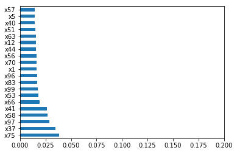

```python
rf = RandomForestClassifier(random_state=42)
rf.fit(train_transformed_final, train['y'])
feat_importances = pd.Series(rf.feature_importances_, index = train_transformed_final.columns)
feat_importances.nlargest(20).plot(kind='barh')
plt.xlim(0,0.2)
plt.show()
```

```python
selected_feature_rf = feat_importances.nlargest(60).index
clf = LogisticRegression()
cv = cross_validate(clf, train_transformed_final[selected_feature_rf], train['y'], scoring='roc_auc', cv=5)
cv['test_score'].mean()
```

```
0.9078775796579535
```

Random forest ranks features based on its contribution to the decrease in impurity. After experimenting with different numbers of features, I found that a smaller number of features gave us similar auc as our baseline model. Generally, we would prefer a smaller model if they have similar performance.

Below is a summary of cv AUC the model achieved with different numbers of features, and I decided to proceed with top 60 features.